# EffectTemp_Predation_Whelks

Esteban Agudo

2024-02-19

#TEMPERATURE EFFECT ON PREDATION IN THE GALAPAGOS

In this study we measured the role of temperature on moderating predation in a system exposed to seasonal upwelling, The Galapagos, both in the lab and the field.

In this documents we show the code for:

Loading packages

```r
library(dplyr) #organizing, cleaning, and filtering data
library(tidyr) #organizing, cleaning, and filtering data
library(ggplot2) #plotting data
library("rnaturalearth") # for building maps
library("rnaturalearthdata") # for building maps
library("sf")
library("ggspatial")
library(tidyverse)
library(sf)
library(wesanderson) #These is a nice looking color palette I use something
library(gridExtra)
library(ggpubr)
library(multcomp) # to conduct pairwise comparations
library(DescTools) # to conduct pairwise comparations
```

## Map of the Study Location

Loading file. We used a shape file I downloaded from a Ecuadoring Navy website

```r
shp_islas <-  read_sf("ShapeIslas/islas.shp")
Barcaza<-read.csv(file="Map.csv", header=T) #plot with site coordates

pal <- wes_palette("Zissou1", 100, type = "continuous")
```

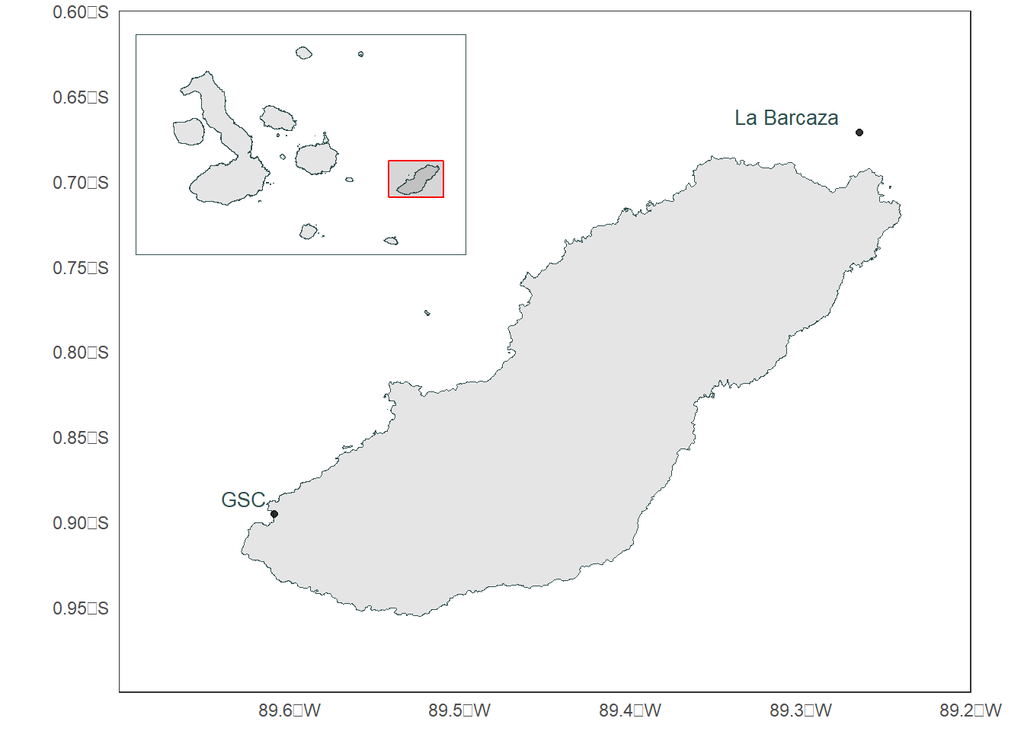

```r
#Select San Cristobal Area.  Let's create a data frame with coordinates for arectangle for San Cristobal

SanCristobal<-data.frame(x=c(-89.70, -89.2, -89.2, -89.7), y= c(-0.65, -0.65, -0.98, -0.98))

#Let's make galapagos map
GalapagosMap<-ggplot(data = shp_islas)+
  geom_sf(color="darkslategray")+
  #let's limit the map area
  coord_sf(xlim = c(-92, -89), ylim = c(-1.5, 0.5),
           expand = FALSE)+
  #let's add a north arrow
  theme_bw()+
  theme(axis.title.x=element_blank(),
        axis.title.y=element_blank(),
        axis.text=element_blank(),
        axis.ticks = element_blank(),
        panel.grid.major =
          element_line(colour = "white"),
        panel.grid.minor =
          element_line(colour = "white"),
          panel.border = element_rect(colour = "darkslategray", fill=NA, size=0.1))+
 geom_polygon(data=SanCristobal, aes(x=x, y=y), color="red", alpha=0.2)

#GalapagosMap
LaBarcaza<-ggplot(data = shp_islas)+
  geom_sf(color="darkslategray")+
  #let's limit the map area
  coord_sf(xlim = c(-89.70, -89.2), ylim = c(-1, -0.6),
           expand = FALSE)+
  geom_point(data=Barcaza,
             aes(x=Longitude, y=Latitude),
             alpha = 0.8, size=1.5, hjust=0.5)+
  geom_text(data=Barcaza,
             aes(x=Longitude, y=Latitude, label=Locality), color = "darkslategray", size = 3.5, hjust=1.2, vjust=-0.5)+
  #scale_size(range = c(1,3))+
  theme_bw()+
  theme(axis.title.x=element_blank(),
        axis.title.y=element_blank(),
      axis.ticks = element_blank(),
    panel.grid.major = element_line(colour = "white"), legend.position="none")


Map_Barcaza<-
LaBarcaza+annotation_custom(grob = ggplotGrob(GalapagosMap),
                    xmin=-89.70, xmax=-89.49, ymin=-0.76, ymax=-0.60)

Map_Barcaza
```

```r
#Figure 1: Study location
#png("Figures/Fig1_Map.png", width=22, height=13, units="cm", res=300)
#print(Map_Barcaza)
#dev.off()
```

## Temperature variation in La Barcaza

We are building a figure were we showed temperature variation in la Barcaza for one year and mark with color the period of times where we conducted our experiments.

```r
library(lubridate)
Barcaza_Temp<-read.csv("TemperatureBarcaza.csv", header=TRUE)
str(Barcaza_Temp)
```

```
## 'data.frame':    51868 obs. of  3 variables:
##  $ time    : chr  "6/26/2022 17:45" "6/26/2022 17:55" "6/26/2022 18:05" "6/26/2022 18:15" ...
##  $ temp    : num  24.8 24.8 24.8 22.6 21.8 21.5 21.7 21.5 20.7 21.4 ...
##  $ Locality: chr  "LaBarcaza" "LaBarcaza" "LaBarcaza" "LaBarcaza" ...
```

```r
#we need to define Barcaza_Temp as a time factor

Barcaza_Temp$DateTime<-as.POSIXct(Barcaza_Temp$time,
                                   format = "%m/%d/%Y %H:%M") # to keep only the day
str(Barcaza_Temp)
```

```
## 'data.frame':    51868 obs. of  4 variables:
##  $ time    : chr  "6/26/2022 17:45" "6/26/2022 17:55" "6/26/2022 18:05" "6/26/2022 18:15" ...
##  $ temp    : num  24.8 24.8 24.8 22.6 21.8 21.5 21.7 21.5 20.7 21.4 ...
##  $ Locality: chr  "LaBarcaza" "LaBarcaza" "LaBarcaza" "LaBarcaza" ...
##  $ DateTime: POSIXct, format: "2022-06-26 17:45:00" "2022-06-26 17:55:00" ...
```

```r
head(Barcaza_Temp)
```

```
##              time temp  Locality            DateTime
## 1 6/26/2022 17:45 24.8 LaBarcaza 2022-06-26 17:45:00
## 2 6/26/2022 17:55 24.8 LaBarcaza 2022-06-26 17:55:00
## 3 6/26/2022 18:05 24.8 LaBarcaza 2022-06-26 18:05:00
## 4 6/26/2022 18:15 22.6 LaBarcaza 2022-06-26 18:15:00
## 5 6/26/2022 18:25 21.8 LaBarcaza 2022-06-26 18:25:00
## 6 6/26/2022 18:35 21.5 LaBarcaza 2022-06-26 18:35:00
```

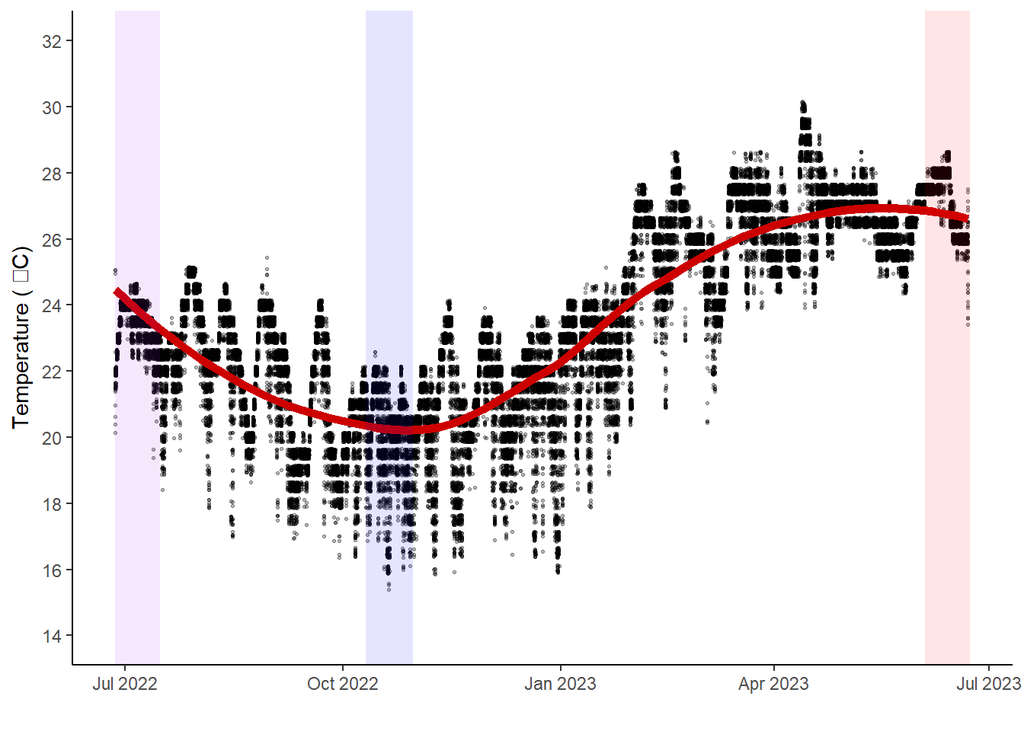

```r
library(plyr)
Barcaza_Temp$Temperature<-round_any(Barcaza_Temp$temp, 0.5)


#another way to separete in case we want to separate day and time
#Barcaza_Temp<- Barcaza_Temp %>%
#  separate(Barcaza_Temp, time, c("date", "time"), sep = " ")

#daily_Barcaza_Temp<-Barcaza_Temp %>%
 # group_by(day) %>%
  #summarise(daily_temp=mean(temp))


Temp_Barcaza<-
  ggplot(Barcaza_Temp, aes(x=DateTime, y=Temperature, na.rm=TRUE))+
  geom_jitter(size=0.5, na.rm=TRUE, height = 0.15, alpha=0.3)+
  geom_smooth(method = "loess", se = FALSE, na.rm=TRUE, color="red3", size=2)+
  theme_classic()+
  theme(panel.background = element_blank())+
  xlab("")+
  ylab(expression("Temperature ("*~degree*C*")"))+
  scale_y_continuous(limits = c(14, 32), breaks = seq(14, 32, 2))+
  annotate("rect", xmin = as.POSIXct("2022-10-10 17:45:00"), xmax = as.POSIXct("2022-10-30 17:45:00 "), ymin = -Inf, ymax = Inf, alpha = .1,fill = "blue")+
    annotate("rect", xmin = as.POSIXct("2023-06-03 17:45:00"), xmax = as.POSIXct("2023-06-22 17:45:00 "), ymin = -Inf, ymax = Inf, alpha = .1,fill = "red")+
  annotate("rect", xmin = as.POSIXct("2022-06-26 17:45:00"), xmax = as.POSIXct("2022-07-15 17:45:00 "), ymin = -Inf, ymax = Inf, alpha = .1,fill = "purple")

Temp_Barcaza
```

```r
#Figure 2: Temperature variation in la Barcaza
#png("Figures/Fig2_Temperature2.png", width=22, height=13, units="cm", res=300)
#print(Temp_Barcaza)
#dev.off()
```

## Effect of temperature on predation and activity in lab experiments

```r
lab_exp<- read.csv("LabPredation.csv", header=TRUE) #loading data
head(lab_exp)
```

```
##   Aquarium Treatment BarnacleEaten DaysExperiment BarnacleEatenPerDay Movement
## 1        1        16             1             21          0.04761905        1
## 2        3        16             0             21          0.00000000        4
## 3        4        16             0             21          0.00000000        1
## 4        6        16             0             21          0.00000000        2
## 5        8        16             1             21          0.04761905        3
## 6       14        16             0             21          0.00000000        3
##   MovementPerDay n
## 1         0.0625 8
## 2         0.2500 8
## 3         0.0625 8
## 4         0.1250 8
## 5         0.1875 8
## 6         0.1875 8
```

```r
str(lab_exp)
```

```
## 'data.frame':    27 obs. of  8 variables:
##  $ Aquarium           : int  1 3 4 6 8 14 16 19 22 23 ...
##  $ Treatment          : int  16 16 16 16 16 16 16 16 21 21 ...
##  $ BarnacleEaten      : int  1 0 0 0 1 0 0 0 0 0 ...
##  $ DaysExperiment     : int  21 21 21 21 21 21 21 21 15 15 ...
##  $ BarnacleEatenPerDay: num  0.0476 0 0 0 0.0476 ...
##  $ Movement           : int  1 4 1 2 3 3 5 1 10 16 ...
##  $ MovementPerDay     : num  0.0625 0.25 0.0625 0.125 0.1875 ...
##  $ n                  : int  8 8 8 8 8 8 8 8 6 6 ...
```

```r
lab_exp$Treatment<-factor(lab_exp$Treatment)#we need to make treatment factor and not numeric

str(lab_exp)
```

```
## 'data.frame':    27 obs. of  8 variables:
##  $ Aquarium           : int  1 3 4 6 8 14 16 19 22 23 ...
##  $ Treatment          : Factor w/ 4 levels "16","21","26",..: 1 1 1 1 1 1 1 1 2 2 ...
##  $ BarnacleEaten      : int  1 0 0 0 1 0 0 0 0 0 ...
##  $ DaysExperiment     : int  21 21 21 21 21 21 21 21 15 15 ...
##  $ BarnacleEatenPerDay: num  0.0476 0 0 0 0.0476 ...
##  $ Movement           : int  1 4 1 2 3 3 5 1 10 16 ...
##  $ MovementPerDay     : num  0.0625 0.25 0.0625 0.125 0.1875 ...
##  $ n                  : int  8 8 8 8 8 8 8 8 6 6 ...
```

```r
head(lab_exp)
```

```
##   Aquarium Treatment BarnacleEaten DaysExperiment BarnacleEatenPerDay Movement
## 1        1        16             1             21          0.04761905        1
## 2        3        16             0             21          0.00000000        4
## 3        4        16             0             21          0.00000000        1
## 4        6        16             0             21          0.00000000        2
## 5        8        16             1             21          0.04761905        3
## 6       14        16             0             21          0.00000000        3
##   MovementPerDay n
## 1         0.0625 8
## 2         0.2500 8
## 3         0.0625 8
## 4         0.1250 8
## 5         0.1875 8
## 6         0.1875 8
```

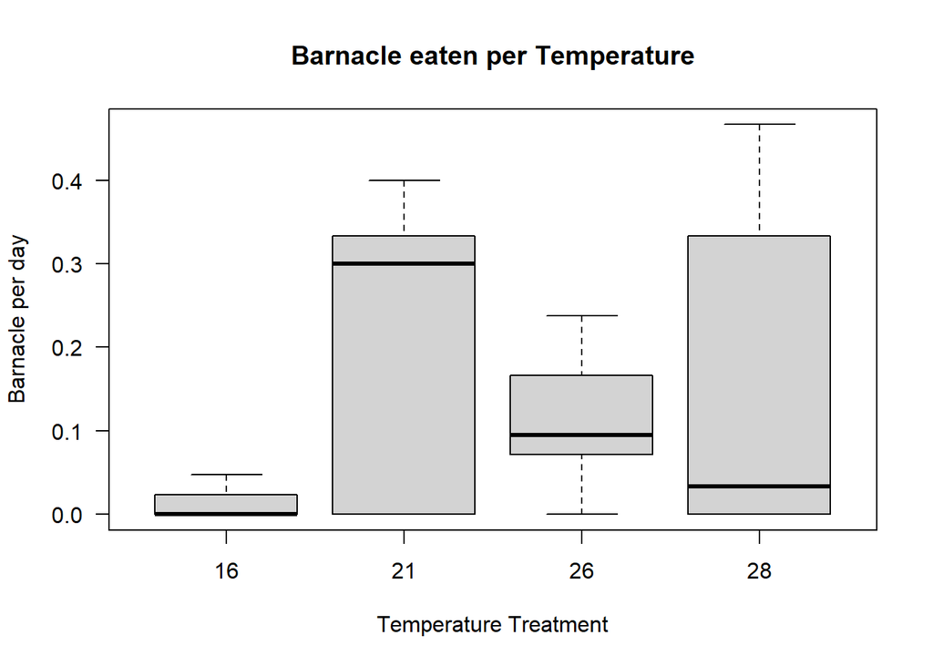

```r
#lets visualize data
boxplot(lab_exp$BarnacleEatenPerDay~lab_exp$Treatment, las=1, ylab="Barnacle per day", xlab="Temperature Treatment", main="Barnacle eaten per Temperature")
```

Testing normality my data

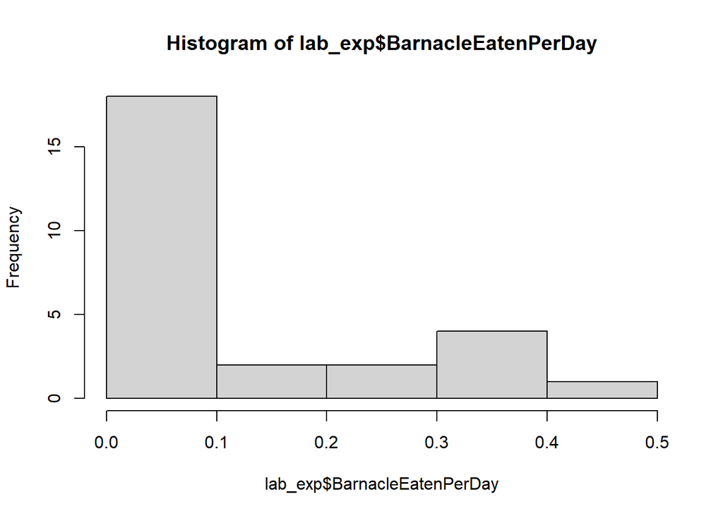

```r
hist(lab_exp$BarnacleEatenPerDay)
```

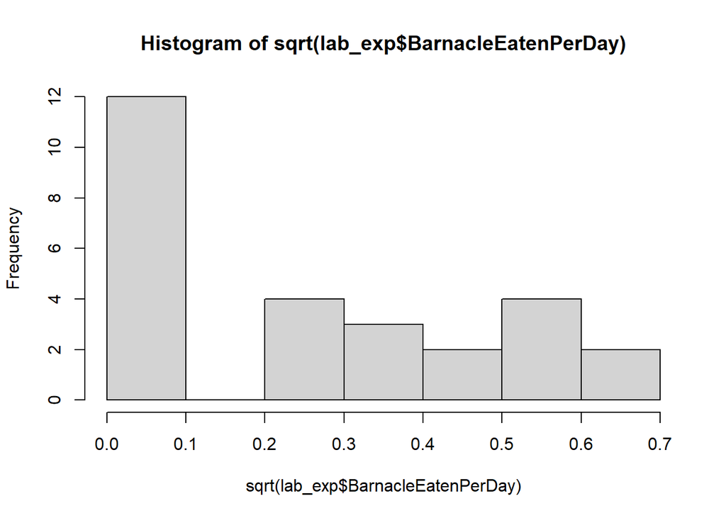

```r
hist(sqrt(lab_exp$BarnacleEatenPerDay))
```

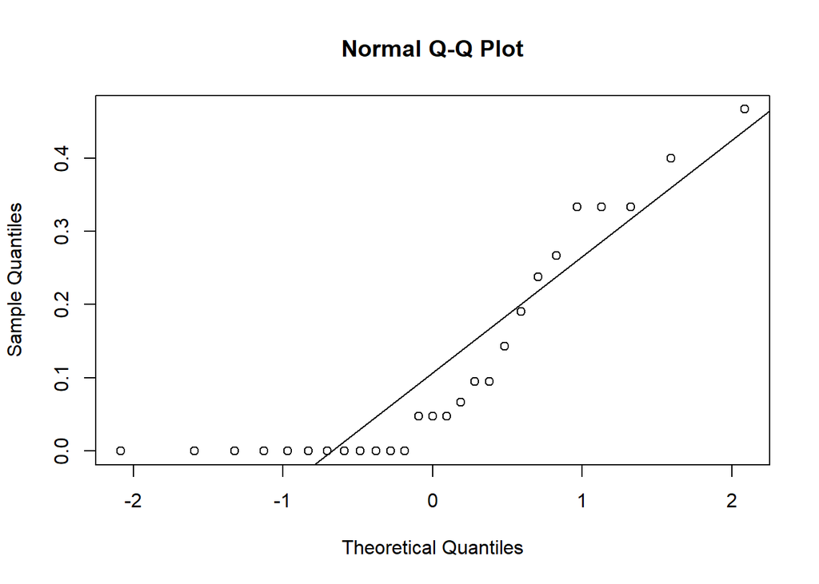

```r
qqnorm(lab_exp$BarnacleEatenPerDay)
qqline(lab_exp$BarnacleEatenPerDay)
```

```r
shapiro.test(lab_exp$BarnacleEatenPerDay)
```

```
##
##  Shapiro-Wilk normality test
##
## data:  lab_exp$BarnacleEatenPerDay
## W = 0.78112, p-value = 6.559e-05
```

My data is no normal, what model to use? Data is quite skewed to the left, so probably a glm with gamma data would be the most useful. For gamma distribution we cannot have zeros, so make sure that we add a constat (+1) when conducting our model. We cannot use poison because poisson requires number with no decimals, only for counting data. Our data was count, however, we conducted experiments with different amount of time, so we are normalizing by predation per day, and that is the reason we have decimal numbers. We did poisson models using the offset parameters also, just to compared with our results from the gamma model.

### Modelling effect of temperature on lab predation rates

```r
#modelo poisson
model_poisson<-glm(BarnacleEaten~Treatment+offset(log(DaysExperiment)), family=quasipoisson(link="log"), data=lab_exp) # we use offset because Poisson model only can consider number without decimals.
summary(model_poisson) #model conclude every temperature is different from 16C
```

```
##
## Call:
## glm(formula = BarnacleEaten ~ Treatment + offset(log(DaysExperiment)),
##     family = quasipoisson(link = "log"), data = lab_exp)
##
## Deviance Residuals:
##     Min       1Q   Median       3Q      Max
## -2.5820  -0.9638  -0.7071   0.8854   2.5983
##
## Coefficients:
##             Estimate Std. Error t value Pr(>|t|)
## (Intercept)  -4.4308     0.9947  -4.455 0.000181 ***
## Treatment21   2.9267     1.0432   2.806 0.010042 *
## Treatment26   2.2736     1.0515   2.162 0.041250 *
## Treatment28   2.4960     1.0684   2.336 0.028566 *
## ---
## Signif. codes:  0 '***' 0.001 '**' 0.01 '*' 0.05 '.' 0.1 ' ' 1
##
## (Dispersion parameter for quasipoisson family taken to be 1.978674)
##
##     Null deviance: 87.360  on 26  degrees of freedom
## Residual deviance: 54.554  on 23  degrees of freedom
## AIC: NA
##
## Number of Fisher Scoring iterations: 6
```

```r
TukeyHSD(aov(model_poisson))
```

```
##   Tukey multiple comparisons of means
##     95% family-wise confidence level
##
## Fit: aov(formula = model_poisson)
##
## $Treatment
##              diff        lwr      upr     p adj
## 21-16  3.41980557  0.2820824 6.557529 0.0291982
## 26-16  2.17857143 -0.8283553 5.185498 0.2152635
## 28-16  2.25313890 -0.8845843 5.390862 0.2217706
## 26-21 -1.24123414 -4.4735832 1.991115 0.7150184
## 28-21 -1.16666667 -4.5210338 2.187700 0.7716837
## 28-26  0.07456747 -3.1577816 3.306917 0.9999037
```

```r
lab_exp$Treatment<-relevel(lab_exp$Treatment, ref="21") # we are releveling to compare with Temperature=21

model_poisson<-glm(BarnacleEaten~Treatment+offset(log(DaysExperiment)), family=quasipoisson(link="log"), data=lab_exp) # we use offset because Poisson model only can consider number without decimals.
summary(model_poisson) #model conclude that only 16 is different from our reference that is 21
```

```
##
## Call:
## glm(formula = BarnacleEaten ~ Treatment + offset(log(DaysExperiment)),
##     family = quasipoisson(link = "log"), data = lab_exp)
##
## Deviance Residuals:
##     Min       1Q   Median       3Q      Max
## -2.5820  -0.9638  -0.7071   0.8854   2.5983
##
## Coefficients:
##             Estimate Std. Error t value Pr(>|t|)
## (Intercept)  -1.5041     0.3145  -4.782 8.02e-05 ***
## Treatment16  -2.9267     1.0432  -2.806    0.010 *
## Treatment26  -0.6531     0.4640  -1.408    0.173
## Treatment28  -0.4308     0.5011  -0.860    0.399
## ---
## Signif. codes:  0 '***' 0.001 '**' 0.01 '*' 0.05 '.' 0.1 ' ' 1
##
## (Dispersion parameter for quasipoisson family taken to be 1.978674)
##
##     Null deviance: 87.360  on 26  degrees of freedom
## Residual deviance: 54.554  on 23  degrees of freedom
## AIC: NA
##
## Number of Fisher Scoring iterations: 6
```

```r
lab_exp$Treatment<-relevel(lab_exp$Treatment, ref="28") # we are releveling to compare with Temperature==28
model_poisson<-glm(BarnacleEaten~Treatment+offset(log(DaysExperiment)), family=quasipoisson(link="log"), data=lab_exp) # we use offset because Poisson model only can consider number without decimals.
summary(model_poisson) #model conclude that only 16 is different from our reference that is 28. So, in conclussion, 16 is different from 21, 26, and 28, but they are not statistically different among then.
```

```
##
## Call:
## glm(formula = BarnacleEaten ~ Treatment + offset(log(DaysExperiment)),
##     family = quasipoisson(link = "log"), data = lab_exp)
##
## Deviance Residuals:
##     Min       1Q   Median       3Q      Max
## -2.5820  -0.9638  -0.7071   0.8854   2.5983
##
## Coefficients:
##             Estimate Std. Error t value Pr(>|t|)
## (Intercept)  -1.9349     0.3901  -4.959 5.16e-05 ***
## Treatment21   0.4308     0.5011   0.860   0.3989
## Treatment16  -2.4960     1.0684  -2.336   0.0286 *
## Treatment26  -0.2224     0.5183  -0.429   0.6719
## ---
## Signif. codes:  0 '***' 0.001 '**' 0.01 '*' 0.05 '.' 0.1 ' ' 1
##
## (Dispersion parameter for quasipoisson family taken to be 1.978674)
##
##     Null deviance: 87.360  on 26  degrees of freedom
## Residual deviance: 54.554  on 23  degrees of freedom
## AIC: NA
##
## Number of Fisher Scoring iterations: 6
```

```r
#With model gamma, which should be the more adecuate model
lab_exp$Treatment<-relevel(lab_exp$Treatment, ref="16") # we are releveling to compare with Temperature=21
model_gamma<-glm((BarnacleEatenPerDay+0.01)~Treatment, family=Gamma, data=lab_exp) # gamma model cannot consider 0s, so we added a 0.1 constant to everybody
summary(model_gamma) # model conclude everybody is is different from 16 (21, 26, and 28)
```

```
##
## Call:
## glm(formula = (BarnacleEatenPerDay + 0.01) ~ Treatment, family = Gamma,
##     data = lab_exp)
##
## Deviance Residuals:
##     Min       1Q   Median       3Q      Max
## -2.0920  -0.6937  -0.6273   0.4624   1.3852
##
## Coefficients:
##             Estimate Std. Error t value Pr(>|t|)
## (Intercept)    45.65      15.52   2.941  0.00734 **
## Treatment28   -39.18      15.73  -2.491  0.02041 *
## Treatment21   -41.35      15.62  -2.648  0.01438 *
## Treatment26   -37.69      15.79  -2.387  0.02559 *
## ---
## Signif. codes:  0 '***' 0.001 '**' 0.01 '*' 0.05 '.' 0.1 ' ' 1
##
## (Dispersion parameter for Gamma family taken to be 0.9250278)
##
##     Null deviance: 51.504  on 26  degrees of freedom
## Residual deviance: 33.685  on 23  degrees of freedom
## AIC: -65.808
##
## Number of Fisher Scoring iterations: 6
```

```r
#let's relevel to compared everybody with 28
lab_exp$Treatment<-relevel(lab_exp$Treatment, ref="21") # we are releveling to compare with
model_gamma<-glm((BarnacleEatenPerDay+0.01)~Treatment, family=Gamma, data=lab_exp) # gamma model cannot consider 0s, so we added a 0.1 constant to everybody
summary(model_gamma) # model conclude that  28 is significantive different from 16, but 21 and 26 are not
```

```
##
## Call:
## glm(formula = (BarnacleEatenPerDay + 0.01) ~ Treatment, family = Gamma,
##     data = lab_exp)
##
## Deviance Residuals:
##     Min       1Q   Median       3Q      Max
## -2.0920  -0.6937  -0.6273   0.4624   1.3852
##
## Coefficients:
##             Estimate Std. Error t value Pr(>|t|)
## (Intercept)    4.306      1.691   2.547   0.0180 *
## Treatment16   41.346     15.615   2.648   0.0144 *
## Treatment28    2.169      3.053   0.710   0.4846
## Treatment26    3.653      3.351   1.090   0.2870
## ---
## Signif. codes:  0 '***' 0.001 '**' 0.01 '*' 0.05 '.' 0.1 ' ' 1
##
## (Dispersion parameter for Gamma family taken to be 0.9250278)
##
##     Null deviance: 51.504  on 26  degrees of freedom
## Residual deviance: 33.685  on 23  degrees of freedom
## AIC: -65.808
##
## Number of Fisher Scoring iterations: 6
```

```r
#let's relevel to compared everybody with 26
lab_exp$Treatment<-relevel(lab_exp$Treatment, ref="26") # we are releveling to compare with
model_gamma<-glm((BarnacleEatenPerDay+0.01)~Treatment, family=Gamma, data=lab_exp) # gamma model cannot consider 0s, so we added a 0.1 constant to everybody
summary(model_gamma) # model conclude that  26 is significantive different from 16, but 21 and 28 are not
```

```
##
## Call:
## glm(formula = (BarnacleEatenPerDay + 0.01) ~ Treatment, family = Gamma,
##     data = lab_exp)
##
## Deviance Residuals:
##     Min       1Q   Median       3Q      Max
## -2.0920  -0.6937  -0.6273   0.4624   1.3852
##
## Coefficients:
##             Estimate Std. Error t value Pr(>|t|)
## (Intercept)    7.959      2.893   2.751   0.0114 *
## Treatment21   -3.653      3.351  -1.090   0.2870
## Treatment16   37.693     15.791   2.387   0.0256 *
## Treatment28   -1.484      3.851  -0.385   0.7035
## ---
## Signif. codes:  0 '***' 0.001 '**' 0.01 '*' 0.05 '.' 0.1 ' ' 1
##
## (Dispersion parameter for Gamma family taken to be 0.9250278)
##
##     Null deviance: 51.504  on 26  degrees of freedom
## Residual deviance: 33.685  on 23  degrees of freedom
## AIC: -65.808
##
## Number of Fisher Scoring iterations: 6
```

```r
#let's relevel to compared everybody with 26
lab_exp$Treatment<-relevel(lab_exp$Treatment, ref="28") # we are releveling to compare with
model_gamma<-glm((BarnacleEatenPerDay+0.01)~Treatment, family=Gamma, data=lab_exp) # gamma model cannot consider 0s, so we added a 0.1 constant to everybody
summary(model_gamma) # model conclude that  26 is significantive different from 16, but 21 and 28 are not
```

```
##
## Call:
## glm(formula = (BarnacleEatenPerDay + 0.01) ~ Treatment, family = Gamma,
##     data = lab_exp)
##
## Deviance Residuals:
##     Min       1Q   Median       3Q      Max
## -2.0920  -0.6937  -0.6273   0.4624   1.3852
##
## Coefficients:
##             Estimate Std. Error t value Pr(>|t|)
## (Intercept)    6.475      2.542   2.547   0.0180 *
## Treatment26    1.484      3.851   0.385   0.7035
## Treatment21   -2.169      3.053  -0.710   0.4846
## Treatment16   39.177     15.730   2.491   0.0204 *
## ---
## Signif. codes:  0 '***' 0.001 '**' 0.01 '*' 0.05 '.' 0.1 ' ' 1
##
## (Dispersion parameter for Gamma family taken to be 0.9250278)
##
##     Null deviance: 51.504  on 26  degrees of freedom
## Residual deviance: 33.685  on 23  degrees of freedom
## AIC: -65.808
##
## Number of Fisher Scoring iterations: 6
```

In conclussion, our model says that 21, 26, and 28 are statistically significantly different from 16 but are not different between them

### Plot showing the effect of temperature on predation rates in the lab

We will build a plot showing mean from each treatmment with standard error (sd/sqrt(n)), indicating significance differences.

```r
#let's summarise mean, sd, and calculate se

lab_exp$Treatment<-relevel(lab_exp$Treatment, ref="16") # we are releveling so our plot is in order

levels(lab_exp$Treatment)
```

```
## [1] "16" "28" "26" "21"
```

```r
lab_exp$Treatment<-factor(lab_exp$Treatment, levels=c("16", "21", "26", "28"))
levels(lab_exp$Treatment)
```

```
## [1] "16" "21" "26" "28"
```

```r
summary_lab_exp<-lab_exp %>%
  dplyr::select(BarnacleEatenPerDay, Treatment, n) %>%
  dplyr::group_by(Treatment)%>%
  dplyr::summarise(mean=mean(BarnacleEatenPerDay), sd=sd(BarnacleEatenPerDay), n=mean(n)) %>%
    dplyr::mutate(se=sd/sqrt(n))

head(lab_exp)
```

```
##   Aquarium Treatment BarnacleEaten DaysExperiment BarnacleEatenPerDay Movement
## 1        1        16             1             21          0.04761905        1
## 2        3        16             0             21          0.00000000        4
## 3        4        16             0             21          0.00000000        1
## 4        6        16             0             21          0.00000000        2
## 5        8        16             1             21          0.04761905        3
## 6       14        16             0             21          0.00000000        3
##   MovementPerDay n
## 1         0.0625 8
## 2         0.2500 8
## 3         0.0625 8
## 4         0.1250 8
## 5         0.1875 8
## 6         0.1875 8
```

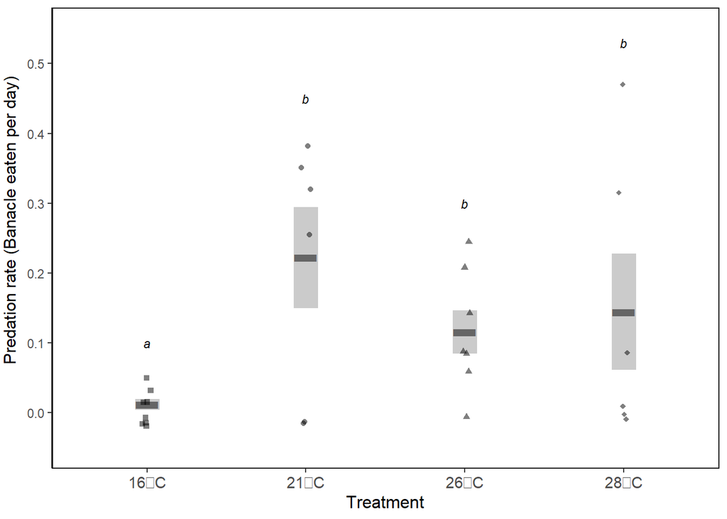

```r
# let's plot FR (feeding rates)
plot_FR_lab<-ggplot()+
    geom_point(data=summary_lab_exp, aes(x=Treatment, y=mean), shape="-", size = 20, position = position_dodge(width = 0.85))+
    geom_errorbar(data=summary_lab_exp, aes(x=Treatment, ymin=mean-se, ymax=mean+se),  size = 8, width = 0, alpha = 0.6, position = position_dodge(width = 0.85), color="darkgrey")+
    geom_jitter(data=lab_exp, aes(x=Treatment, y=BarnacleEatenPerDay, shape=Treatment), size=1.5, alpha=0.5, position = position_jitterdodge(jitter.width = 0.2, jitter.height = 0.02, dodge.width = 0.85))+
    theme_classic()+
    theme(panel.border = element_rect(colour = "black", fill=NA, size=0.7),
        legend.position="none", axis.text.x = element_text(size = 11), axis.title.y = element_text(size = 11.5, hjust = 0.6, vjust = 2.5), axis.title.x = element_text(size = 12))+
  ylab("Predation rate (Banacle eaten per day)")+
    xlab(expression("Treatment"))+
  scale_y_continuous(limits = c(-0.05, 0.55), breaks = seq(0, .55, 0.1))+
    annotate("text",
           x = 1,
           y = 0.1,
           label = "a",
           family = "", fontface = 3, size=3)+
     annotate("text",
           x = 2,
           y = 0.45,
           label = "b",
           family = "", fontface = 3, size=3)+
   annotate("text",
           x = 3,
           y = 0.3,
           label = "b",
           family = "", fontface = 3, size=3)+
   annotate("text",
           x = 4,
           y = 0.53,
           label = "b",
           family = "", fontface = 3, size=3)+
    scale_shape_manual(values=c(15, 16, 17, 18))+
  scale_x_discrete(labels = c(expression('16'*degree*C),expression('21'*degree*C), expression('26'*degree*C), expression('28'*degree*C)))

plot_FR_lab
```

## Effect of temperature on whelk movement rate

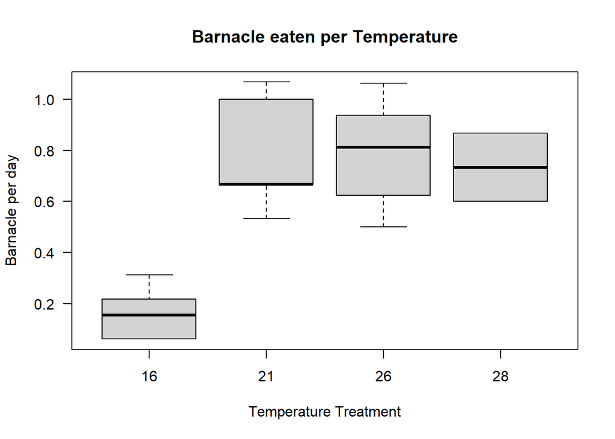

```r
#lab_exp<- read.csv("LabPredation.csv", header=TRUE)
#lets visualize data
boxplot(lab_exp$MovementPerDay~lab_exp$Treatment, las=1, ylab="Barnacle per day", xlab="Temperature Treatment", main="Barnacle eaten per Temperature")
```

### Modelling effect of temperature on movement

```r
model_poisson_mov<-glm(Movement~Treatment+offset(log(DaysExperiment)), family=poisson(link="log"), data=lab_exp) # we use offset because Poisson model only can consider number without decimals
summary(model_poisson_mov)
```

```
##
## Call:
## glm(formula = Movement ~ Treatment + offset(log(DaysExperiment)),
##     family = poisson(link = "log"), data = lab_exp)
##
## Deviance Residuals:
##     Min       1Q   Median       3Q      Max
## -1.3824  -0.6228   0.0000   0.6253   1.3898
##
## Coefficients:
##             Estimate Std. Error z value Pr(>|z|)
## (Intercept)  -2.1282     0.2236  -9.518  < 2e-16 ***
## Treatment21   1.8625     0.2539   7.334 2.23e-13 ***
## Treatment26   1.6151     0.2477   6.520 7.02e-11 ***
## Treatment28   1.8181     0.2552   7.123 1.06e-12 ***
## ---
## Signif. codes:  0 '***' 0.001 '**' 0.01 '*' 0.05 '.' 0.1 ' ' 1
##
## (Dispersion parameter for poisson family taken to be 1)
##
##     Null deviance: 110.589  on 26  degrees of freedom
## Residual deviance:  17.843  on 23  degrees of freedom
## AIC: 128.67
##
## Number of Fisher Scoring iterations: 4
```

```r
model_gamma_mov<-glm((MovementPerDay+0.01)~Treatment, family=Gamma, data=lab_exp) # gamma model cannot consider 0
summary(model_gamma_mov)
```

```
##
## Call:
## glm(formula = (MovementPerDay + 0.01) ~ Treatment, family = Gamma,
##     data = lab_exp)
##
## Deviance Residuals:
##     Min       1Q   Median       3Q      Max
## -0.7294  -0.1963   0.0000   0.1786   0.7446
##
## Coefficients:
##             Estimate Std. Error t value Pr(>|t|)
## (Intercept)   6.0150     0.7917   7.598 1.03e-07 ***
## Treatment21  -4.7275     0.8155  -5.797 6.61e-06 ***
## Treatment26  -4.7583     0.8112  -5.866 5.60e-06 ***
## Treatment28  -4.6697     0.8176  -5.711 8.14e-06 ***
## ---
## Signif. codes:  0 '***' 0.001 '**' 0.01 '*' 0.05 '.' 0.1 ' ' 1
##
## (Dispersion parameter for Gamma family taken to be 0.138575)
##
##     Null deviance: 13.7428  on 26  degrees of freedom
## Residual deviance:  3.4311  on 23  degrees of freedom
## AIC: -10.437
##
## Number of Fisher Scoring iterations: 5
```

```r
#in this case is fairly obvious every treatment is different from 16C, and not statistically different from them
```

### Plot showing effect of temperautre on movement

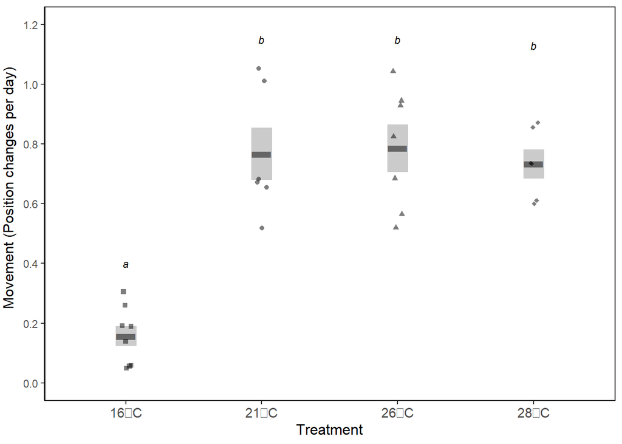

```r
#sumarazing data
summary_lab_exp_mov<-lab_exp %>%
  dplyr::select(MovementPerDay, Treatment, n) %>%
  dplyr::group_by(Treatment)%>%
    dplyr::summarise(mean=mean(MovementPerDay), sd=sd(MovementPerDay), n=mean(n)) %>%
    dplyr::mutate(se=sd/sqrt(n))

#Plotting effect temp on mov
plot_MR_lab<-ggplot()+
    geom_point(data=summary_lab_exp_mov, aes(x=Treatment, y=mean), shape="-", size = 20, position = position_dodge(width = 0.85))+
    geom_errorbar(data=summary_lab_exp_mov, aes(x=Treatment, ymin=mean-se, ymax=mean+se),  size = 8, width = 0, alpha = 0.6, position = position_dodge(width = 0.85),  color="darkgray" )+
    geom_jitter(data=lab_exp, aes(x=Treatment, y=MovementPerDay, shape=Treatment), size=1.5, alpha=0.5, position = position_jitterdodge(jitter.width = 0.25, jitter.height = 0.02, dodge.width = 0.85), show.legend = FALSE)+
    theme_classic()+
    theme(panel.border = element_rect(colour = "black", fill=NA, size=0.7),
        legend.position="none", axis.text.x = element_text(size = 11), axis.title.y = element_text(size = 11.5, hjust = 0.6, vjust = 2.5), axis.title.x = element_text(size = 12))+
  ylab("Movement (Position changes per day)")+
    xlab(expression("Treatment"))+
  scale_y_continuous(limits = c(0, 1.2), breaks = seq(0, 1.2, 0.2))+
    annotate("text",
           x = 1,
           y = 0.4,
           label = "a",
           family = "", fontface = 3, size=3)+
     annotate("text",
           x = 2,
           y = 1.15,
           label = "b",
           family = "", fontface = 3, size=3)+
   annotate("text",
           x = 3,
           y = 1.15,
           label = "b",
           family = "", fontface = 3, size=3)+
   annotate("text",
           x = 4,
           y = 1.13,
           label = "b",
           family = "", fontface = 3, size=3)+
   scale_shape_manual(values=c(15, 16, 17, 18))+
  scale_x_discrete(labels = c(expression('16'*degree*C),expression('21'*degree*C), expression('26'*degree*C), expression('28'*degree*C)))

plot_MR_lab
```

### Combining movemend and feeding plots Combining both plots, movement and feeding rates

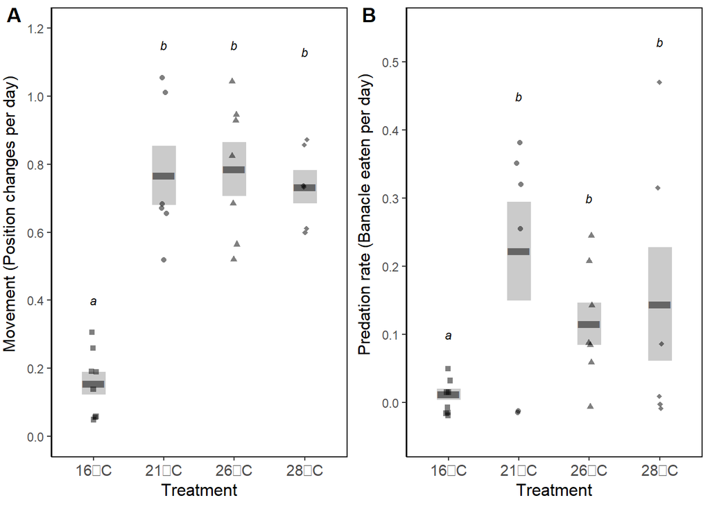

```r
### Effect of temperature on movement and predation
plot_MR_FR<-ggarrange(plot_MR_lab, plot_FR_lab,
          labels = c("A", "B"),
          ncol = 2)

plot_MR_FR
```

```r
#png("Figures/Fig3_TempertureMovementFeeding_Lab_B.png", width=22, height=15, units="cm", res=300)
#print(plot_MR_FR)
#dev.off()
```

## Effect of temperature on predation in the field

```r
field_exp<- read.csv("FieldPredation_BarcazaExp.csv", header=TRUE)
head(field_exp)
```

```
##                Time     Trial Pizza_Number Treatment Temperature
## 1 Cold_October_2022 Cold(20C)           66    Closed          20
## 2 Cold_October_2022 Cold(20C)           68    Closed          20
## 3 Cold_October_2022 Cold(20C)           71    Closed          20
## 4 Cold_October_2022 Cold(20C)           73    Closed          20
## 5 Cold_October_2022 Cold(20C)           74    Closed          20
## 6 Cold_October_2022 Cold(20C)           87    Closed          20
##   Total_Dead_Barnacles DailyPredation NumberDays n
## 1                    0      0.0000000         15 9
## 2                    0      0.0000000         15 9
## 3                    0      0.0000000         15 9
## 4                    0      0.0000000         15 9
## 5                    2      0.1333333         15 9
## 6                    0      0.0000000         15 9
```

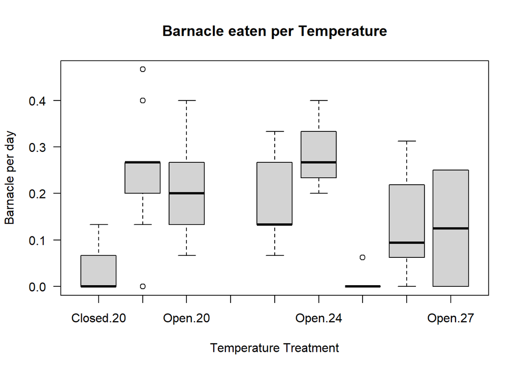

```r
#lets visualize data
boxplot(field_exp$DailyPredation~field_exp$Treatment*field_exp$Temperature, las=1, ylab="Barnacle per day", xlab="Temperature Treatment", main="Barnacle eaten per Temperature")
```

```r
#making sure temperature and treatment are considered factors
field_exp$Temperature<-as.factor(field_exp$Temperature)
field_exp$Treatment<-as.factor(field_exp$Treatment)
```

The 24C treatment was our pilot experiment. We conducted about 8 replicas for Hprinceps inclussion treatment but only three for Open treatment, so let’s remove this one as we have very little statistical power.

```r
library(dplyr)

#field_exp_filter<-field_exp %>%
 # dplyr::filter(!(Temperature=="24" & Treatment=="Open "))

field_exp_filter<-field_exp[-c(35, 36, 37),]
```

Let’s glimpse at how data is distributed

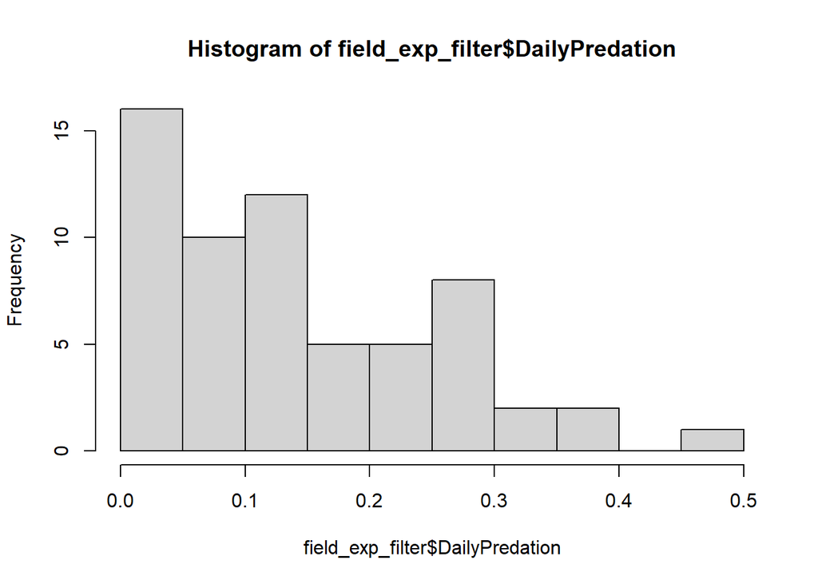

```r
hist(field_exp_filter$DailyPredation)
```

Similarly to the lab experiment, our data seems very skewed toward the left (many whelks don’t eat and most of the one who eats, eats very little). Considering, a glm with family=Gamma is the best option. Again, I have to add 0.01 to make sure I don’t have zeros.

We also have a very unbalanced design where we have three levels of a predation treatment (20 and 27) for two temperature but only one for another (24C). One good option could be to run each predation treatment alone through the temperature levels.

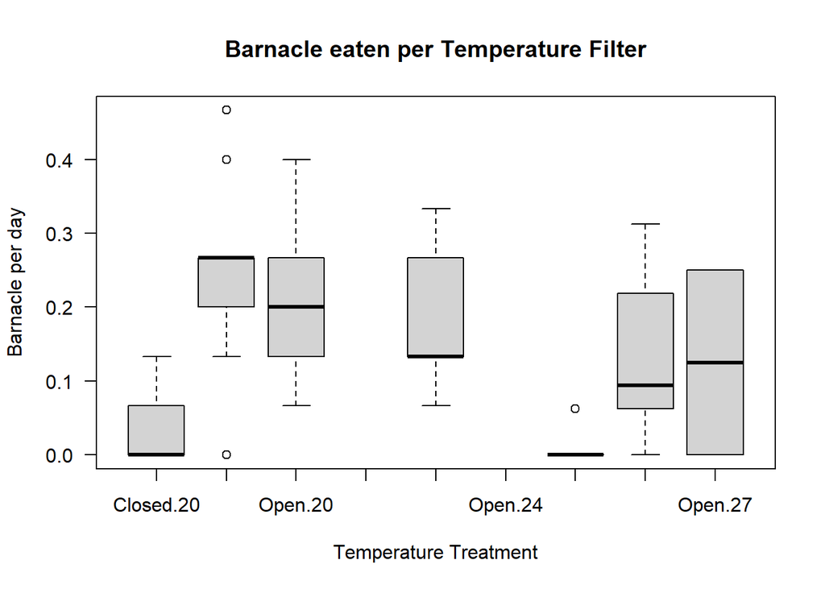

```r
boxplot(field_exp_filter$DailyPredation~field_exp_filter$Treatment*field_exp_filter$Temperature, las=1, ylab="Barnacle per day", xlab="Temperature Treatment", main="Barnacle eaten per Temperature Filter")
```

```r
levels(field_exp_filter$Treatment)
```

```
## [1] "Closed"             "HexaplexInclussion" "Open"
```

```r
levels(field_exp_filter$Temperature)
```

```
## [1] "20" "24" "27"
```

```r
model_gamma_field<-glm((DailyPredation+0.01)~Temperature:Treatment, family=Gamma, data=field_exp_filter) # we add `1 so we don't have zeros
summary(model_gamma_field)
```

```
##
## Call:
## glm(formula = (DailyPredation + 0.01) ~ Temperature:Treatment,
##     family = Gamma, data = field_exp_filter)
##
## Deviance Residuals:
##      Min        1Q    Median        3Q       Max
## -2.14634  -0.71467  -0.03762   0.36334   1.45062
##
## Coefficients: (3 not defined because of singularities)
##                                           Estimate Std. Error t value Pr(>|t|)
## (Intercept)                                  8.163      2.030   4.021 0.000181
## Temperature20:TreatmentClosed               13.097      5.931   2.208 0.031501
## Temperature24:TreatmentClosed                   NA         NA      NA       NA
## Temperature27:TreatmentClosed               36.281     15.761   2.302 0.025217
## Temperature20:TreatmentHexaplexInclussion   -4.344      2.263  -1.919 0.060232
## Temperature24:TreatmentHexaplexInclussion   -3.175      2.514  -1.263 0.211985
## Temperature27:TreatmentHexaplexInclussion   -1.031      2.597  -0.397 0.692888
## Temperature20:TreatmentOpen                 -3.401      2.383  -1.427 0.159254
## Temperature24:TreatmentOpen                     NA         NA      NA       NA
## Temperature27:TreatmentOpen                     NA         NA      NA       NA
##
## (Intercept)                               ***
## Temperature20:TreatmentClosed             *
## Temperature24:TreatmentClosed
## Temperature27:TreatmentClosed             *
## Temperature20:TreatmentHexaplexInclussion .
## Temperature24:TreatmentHexaplexInclussion
## Temperature27:TreatmentHexaplexInclussion
## Temperature20:TreatmentOpen
## Temperature24:TreatmentOpen
## Temperature27:TreatmentOpen
## ---
## Signif. codes:  0 '***' 0.001 '**' 0.01 '*' 0.05 '.' 0.1 ' ' 1
##
## (Dispersion parameter for Gamma family taken to be 0.6184134)
##
##     Null deviance: 73.516  on 60  degrees of freedom
## Residual deviance: 48.903  on 54  degrees of freedom
## AIC: -122.1
##
## Number of Fisher Scoring iterations: 6
```

```r
library(jtools)
summ(model_gamma_field)
```

| Observations | 61 |
| --- | --- |
| Dependent variable | (DailyPredation + 0.01) |
| Type | Generalized linear model |
| Family | Gamma |
| Link | inverse |

| χ²(6) | 24.61 |
| --- | --- |
| Pseudo-R² (Cragg-Uhler) | -0.07 |
| Pseudo-R² (McFadden) | -0.26 |
| AIC | -122.10 |
| BIC | -105.21 |

|  | Est. | S.E. | t val. | p |
| --- | --- | --- | --- | --- |
| (Intercept) | 8.16 | 2.03 | 4.02 | 0.00 |
| Temperature20:TreatmentClosed | 13.10 | 5.93 | 2.21 | 0.03 |
| Temperature24:TreatmentClosed | NA | NA | NA | NA |
| Temperature27:TreatmentClosed | 36.28 | 15.76 | 2.30 | 0.03 |
| Temperature20:TreatmentHexaplexInclussion | -4.34 | 2.26 | -1.92 | 0.06 |
| Temperature24:TreatmentHexaplexInclussion | -3.18 | 2.51 | -1.26 | 0.21 |
| Temperature27:TreatmentHexaplexInclussion | -1.03 | 2.60 | -0.40 | 0.69 |
| Temperature20:TreatmentOpen | -3.40 | 2.38 | -1.43 | 0.16 |
| Temperature24:TreatmentOpen | NA | NA | NA | NA |
| Temperature27:TreatmentOpen | NA | NA | NA | NA |

Standard errors: MLE

```r
library(interactions)
```

```
## Using data field_exp_filter from global environment. This could cause
## incorrect results if field_exp_filter has been altered since the model was
## fit. You can manually provide the data to the "data =" argument.
```

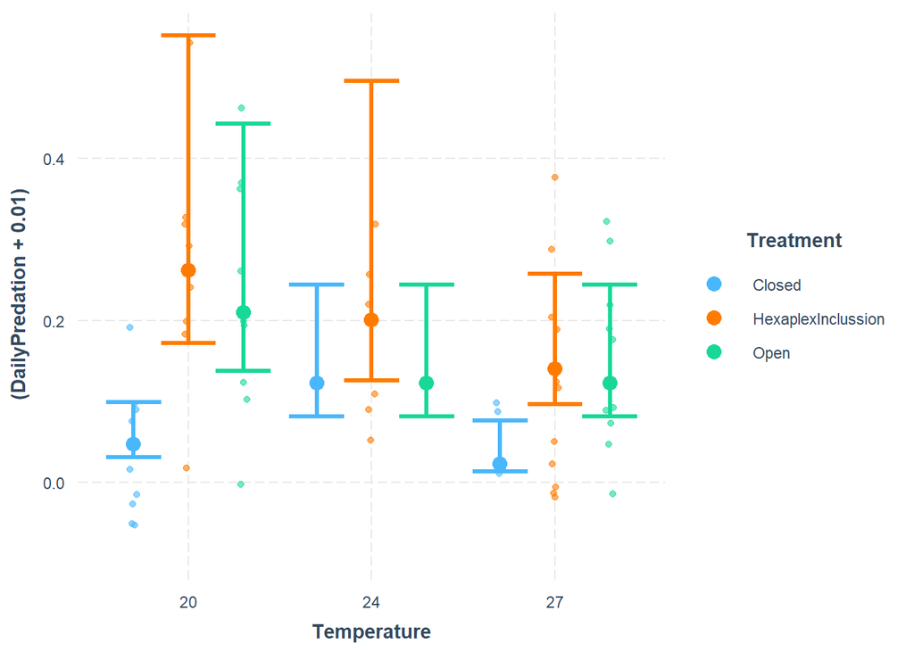

```r
cat_plot(model_gamma_field, pred =Temperature, modx = Treatment, plot.points = TRUE)
```

### Comparing just HexaplexInclussion treatment

```r
field_exp_Hinclussion<-field_exp %>%
  filter(Treatment=="HexaplexInclussion")

field_exp_Hinclussion$Temperature<-factor(field_exp_Hinclussion$Temperature, levels=c("20", "24", "27"))

model_gamma_Hinclussion<-glm((DailyPredation+0.01)~Temperature, family=Gamma, data=field_exp_Hinclussion) # we add `1 so we don't have zeros
summary(model_gamma_Hinclussion) # according to the model 27 is different from 20.
```

```
##
## Call:
## glm(formula = (DailyPredation + 0.01) ~ Temperature, family = Gamma,
##     data = field_exp_Hinclussion)
##
## Deviance Residuals:
##      Min        1Q    Median        3Q       Max
## -2.14634  -0.59436   0.00896   0.36334   0.96662
##
## Coefficients:
##               Estimate Std. Error t value Pr(>|t|)
## (Intercept)     3.8190     0.7946   4.806 6.16e-05 ***
## Temperature24   1.1692     1.4199   0.823   0.4181
## Temperature27   3.3133     1.5109   2.193   0.0378 *
## ---
## Signif. codes:  0 '***' 0.001 '**' 0.01 '*' 0.05 '.' 0.1 ' ' 1
##
## (Dispersion parameter for Gamma family taken to be 0.3896079)
##
##     Null deviance: 19.664  on 27  degrees of freedom
## Residual deviance: 17.621  on 25  degrees of freedom
## AIC: -33.996
##
## Number of Fisher Scoring iterations: 6
```

```r
#let's relevel so we can compared 24 agains 27 and 20
field_exp_Hinclussion$Temperature<-relevel(field_exp_Hinclussion$Temperature, ref="24")

model_gamma_Hinclussion<-glm((DailyPredation+0.01)~Temperature, family=Gamma, data=field_exp_Hinclussion) # we add `1 so we don't have zeros
summary(model_gamma_Hinclussion) # according to the model 24 is not different from 20 or 26
```

```
##
## Call:
## glm(formula = (DailyPredation + 0.01) ~ Temperature, family = Gamma,
##     data = field_exp_Hinclussion)
##
## Deviance Residuals:
##      Min        1Q    Median        3Q       Max
## -2.14634  -0.59436   0.00896   0.36334   0.96662
##
## Coefficients:
##               Estimate Std. Error t value Pr(>|t|)
## (Intercept)      4.988      1.177   4.239 0.000268 ***
## Temperature20   -1.169      1.420  -0.823 0.418067
## Temperature27    2.144      1.743   1.230 0.229977
## ---
## Signif. codes:  0 '***' 0.001 '**' 0.01 '*' 0.05 '.' 0.1 ' ' 1
##
## (Dispersion parameter for Gamma family taken to be 0.3896079)
##
##     Null deviance: 19.664  on 27  degrees of freedom
## Residual deviance: 17.621  on 25  degrees of freedom
## AIC: -33.996
##
## Number of Fisher Scoring iterations: 6
```

```r
#let's compare now differences between temperature for the natural predation (closed) treatment
field_exp_open<-field_exp %>%
  filter(Treatment=="Open")

model_gamma_Open<-glm((DailyPredation+0.01)~Temperature, family=Gamma, data=field_exp_open) # we add `1 so we don't have zeros
summary(model_gamma_Open) #acording to the model there are not differneces between the three temperatures for the open treatment
```

```
##
## Call:
## glm(formula = (DailyPredation + 0.01) ~ Temperature, family = Gamma,
##     data = field_exp_open)
##
## Deviance Residuals:
##     Min       1Q   Median       3Q      Max
## -1.7817  -0.3591   0.0000   0.2890   0.8601
##
## Coefficients:
##               Estimate Std. Error t value Pr(>|t|)
## (Intercept)      4.762      1.106   4.304 0.000383 ***
## Temperature24   -1.416      1.743  -0.813 0.426480
## Temperature27    3.401      2.112   1.610 0.123819
## ---
## Signif. codes:  0 '***' 0.001 '**' 0.01 '*' 0.05 '.' 0.1 ' ' 1
##
## (Dispersion parameter for Gamma family taken to be 0.4858288)
##
##     Null deviance: 19.49  on 21  degrees of freedom
## Residual deviance: 17.04  on 19  degrees of freedom
## AIC: -26.768
##
## Number of Fisher Scoring iterations: 6
```

```r
#let's compare now differences between temperature for the natural predation (closed) treatment
field_exp_closed<-field_exp %>%
  filter(Treatment=="Closed")

model_gamma_Closed<-glm((DailyPredation+0.01)~Temperature, family=Gamma, data=field_exp_closed) # we add `1 so we don't have zeros
summary(model_gamma_Closed) #acording to the model there are not differneces between 20 and 27
```

```
##
## Call:
## glm(formula = (DailyPredation + 0.01) ~ Temperature, family = Gamma,
##     data = field_exp_closed)
##
## Deviance Residuals:
##     Min       1Q   Median       3Q      Max
## -1.2336  -1.2336  -0.7147   0.5318   1.4506
##
## Coefficients:
##               Estimate Std. Error t value Pr(>|t|)
## (Intercept)     21.260      7.832   2.715   0.0188 *
## Temperature27   23.185     23.318   0.994   0.3397
## ---
## Signif. codes:  0 '***' 0.001 '**' 0.01 '*' 0.05 '.' 0.1 ' ' 1
##
## (Dispersion parameter for Gamma family taken to be 1.221296)
##
##     Null deviance: 16.073  on 13  degrees of freedom
## Residual deviance: 14.471  on 12  degrees of freedom
## AIC: -58.9
##
## Number of Fisher Scoring iterations: 6
```

From comparing the Hinclussion treatment model concludes there are significant differences between 20 and 27 C. However, this differences are not the same for the open treatment.

### Plot of the effect of temperature on predation in the field

```r
summary_field_pred<-field_exp %>%
  dplyr::select(DailyPredation, Treatment, Temperature, n) %>%
  dplyr::group_by(Temperature, Treatment)%>%
    dplyr::summarise(mean=mean(DailyPredation), sd=sd(DailyPredation), n=mean(n)) %>%
    dplyr::mutate(se=sd/sqrt(n)) %>%
  dplyr::filter(!(Temperature=="24" & Treatment=="Open"))
summary_field_pred
```

```
## # A tibble: 7 × 6
## # Groups:   Temperature [3]
##   Temperature Treatment            mean     sd     n     se
##   <fct>       <fct>               <dbl>  <dbl> <dbl>  <dbl>
## 1 20          Closed             0.0370 0.0484     9 0.0161
## 2 20          HexaplexInclussion 0.252  0.137      9 0.0455
## 3 20          Open               0.2    0.100      9 0.0333
## 4 24          HexaplexInclussion 0.190  0.0976     7 0.0369
## 5 27          Closed             0.0125 0.0280     5 0.0125
## 6 27          HexaplexInclussion 0.130  0.105     12 0.0302
## 7 27          Open               0.112  0.109     10 0.0346
```

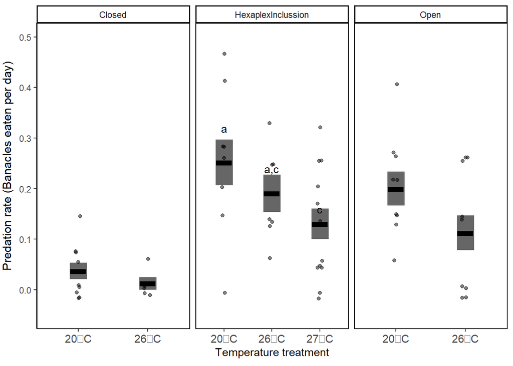

```r
#let's make a data.frame with anotation regarding statistical differences. The only differences occur on the Hexaplex inclussion so they will restricted to that

significance <- data.frame(x=c(1, 2, 3), y=c(0.32, 0.24, 0.16), lab=c("a", "a,c", "c"), Treatment= "HexaplexInclussion")

#Plot
plot_FR_field<-  ggplot()+
    geom_point(data=summary_field_pred, aes(x=Temperature, y=mean), shape="-", size = 20, position = position_dodge(width = 0.85))+
    geom_linerange(data=summary_field_pred, aes(x=Temperature, ymin=mean-se, ymax=mean+se),  size = 8, alpha = 0.6, position = position_dodge(width = 0.85))+
    geom_jitter(data=field_exp_filter, aes(x=Temperature, y=DailyPredation, fill='constant'), size=1.5, alpha=0.5, position = position_jitterdodge(jitter.width = 0.1, jitter.height = 0.02, dodge.width = 0.85))+
  facet_wrap(~ Treatment, scales = "free_x")+ #separating plots by predation treatment
    theme_classic()+
    theme(panel.border = element_rect(colour = "black", fill=NA, size=0.7),
         axis.text.x = element_text(size = 11), axis.title.y = element_text(size = 11.5, hjust = 0.6, vjust = 2.5), legend.position ="none")+  #no legend
  ylab("Predation rate (Banacles eaten per day)")+ #y axis title
    xlab(expression("Temperature treatment"))+ #x axis title
  scale_x_discrete(labels = c(expression('20'*degree*C),expression('26'*degree*C), expression('27'*degree*C)))+
  #guides(colour = guide_legend(override.aes = list(shape = 15, size=3)))+
  scale_y_continuous(limits = c(-0.05, 0.5), breaks = seq(0, 0.5, 0.1))+
  geom_text(data = significance, aes(x = x,  y = y, label = lab)) #adding letters indicating significance levels

plot_FR_field
```